# Etapa 2 del proyecto. La tarea de clasificación: árboles de decisión y K-vecinos más cercanos

## Analisis del problema

El acceso al agua potable segura es un pilar fundamental para la salud humana, un derecho básico y un componente esencial de políticas efectivas de protección sanitaria. Su importancia trasciende lo individual, constituyendo un factor crítico en el desarrollo a nivel nacional, regional y local. La falta de agua potable de calidad no solo impacta la salud pública, sino que también genera costos económicos significativos asociados a enfermedades y tratamientos médicos. En contraparte, se ha demostrado que inversiones estratégicas en infraestructuras de suministro y saneamiento de agua pueden generar beneficios económicos netos, al reducir los efectos adversos en la salud y los gastos sanitarios.

En este contexto, la capacidad de predecir la potabilidad del agua a partir de sus características fisicoquímicas se convierte en una herramienta valiosa para la toma de decisiones informadas y la optimización de recursos. Este proyecto se centra en el desarrollo y evaluación de modelos de Machine Learning, específicamente árboles de decisión y K-vecinos más cercanos, para predecir la potabilidad del agua. El objetivo principal es construir modelos precisos y robustos que puedan identificar los factores clave que influyen en la calidad del agua, y proporcionar una herramienta predictiva que contribuya a la gestión eficiente de los recursos hídricos y a la protección de la salud pública.

## Recoleccion de datos

### Importación de librerías requeridas

Para las diferente etapas de nuestro proceso de Machine Learning por medio de Árboles de Decisión y K-Vecinos más cercanos, utilizaremos diferentes librerías que incluyen desde las más escenciales para la manipulación de datos con Python como pandas y numpy, incluyendo herramientas de visualización como matplotlib y seaborn, hasta diferentes clases de SciKit-Learn para realizar la preparación de datos, construcción de modelos y evaluación de los mismos.

```python
import pandas as pd
import matplotlib.pyplot as plt
import numpy as np
import seaborn as sns

from sklearn.pipeline import Pipeline
from sklearn.impute import SimpleImputer
from sklearn.compose import ColumnTransformer
from sklearn.tree import DecisionTreeClassifier, plot_tree
from sklearn.neighbors import KNeighborsClassifier
from sklearn.preprocessing import StandardScaler, LabelEncoder
from sklearn.model_selection import train_test_split, KFold, GridSearchCV, validation_curve
from sklearn.metrics import classification_report, ConfusionMatrixDisplay, accuracy_score, recall_score, precision_score, f1_score
from imblearn.over_sampling import SMOTE

from importlib.metadata import version

print(f"Versión de Pandas: {version('pandas')}")
print(f"Versión de Matplotlib: {version('matplotlib')}")
print(f"Versión de Scikit-learn: {version('scikit-learn')}")
print(f"Versión de Numpy: {version('numpy')}")
```

```
Versión de Pandas: 2.2.2
Versión de Matplotlib: 3.9.2
Versión de Scikit-learn: 1.6.1
Versión de Numpy: 1.26.4
```

### Carga de datos

```python
ruta_archivo = './Etapa 2 del proyecto/Datos_Etapa-2.csv'
data_raw = pd.read_csv(ruta_archivo, sep=';', na_values=['?'], encoding = 'utf-8')
```

## Exploracion del conjunto de datos

```python
data_raw.head()
```

|  | pH | Dureza | Sólidos | Cloraminas | Sulfatos | Conductividad | Carbono_orgánico | Trihalometanos | Turbidez | Potabilidad |
| --- | --- | --- | --- | --- | --- | --- | --- | --- | --- | --- |
| 0 | NaN | 204.89 | 20791.32 | 7.30 | 368.52 | 564.31 | 10.38 | 86.99 | 2.96 | NO |
| 1 | 3.72 | 129.42 | 18630.06 | 6.64 | NaN | 592.89 | 15.18 | 56.33 | 4.50 | NO |
| 2 | 8.10 | 224.24 | 19909.54 | 9.28 | NaN | 418.61 | 16.87 | 66.42 | 3.06 | NO |
| 3 | 8.32 | 214.37 | 22018.42 | 8.06 | 356.89 | 363.27 | 18.44 | 100.34 | 4.63 | NO |
| 4 | 9.09 | 181.10 | 17978.99 | 6.55 | 310.14 | 398.41 | 11.56 | 32.00 | 4.08 | NO |

```python
data_raw.info()
```

```
<class 'pandas.core.frame.DataFrame'>
RangeIndex: 3276 entries, 0 to 3275
Data columns (total 10 columns):
 #   Column            Non-Null Count  Dtype
---  ------            --------------  -----
 0   pH                2785 non-null   float64
 1   Dureza            3276 non-null   float64
 2   Sólidos           3276 non-null   float64
 3   Cloraminas        3276 non-null   float64
 4   Sulfatos          2495 non-null   float64
 5   Conductividad     3276 non-null   float64
 6   Carbono_orgánico  3276 non-null   float64
 7   Trihalometanos    3114 non-null   float64
 8   Turbidez          3276 non-null   float64
 9   Potabilidad       3276 non-null   object
dtypes: float64(9), object(1)
memory usage: 256.1+ KB
```

Podemos observar que, únicamente la variable objetivo es categoríca, mientras que el resto son variables numéricas. Asimismo, con tan pocos datos se logra identificar la presentcia de datos faltantes. Con una pequeña muestra de los datos (head) de los datos importados vemos que el registro 0 (primero) incluye un valor faltante, iniciando nuestra consideración que los datos faltantes serán determinantes en este ejercicio.

```python
data_raw.describe()
```

|  | pH | Dureza | Sólidos | Cloraminas | Sulfatos | Conductividad | Carbono_orgánico | Trihalometanos | Turbidez |
| --- | --- | --- | --- | --- | --- | --- | --- | --- | --- |
| count | 2785.000000 | 3276.000000 | 3276.000000 | 3276.000000 | 2495.000000 | 3276.000000 | 3276.000000 | 3114.000000 | 3276.000000 |
| mean | 7.080804 | 196.369481 | 22014.092415 | 7.122241 | 333.775784 | 426.205171 | 14.284921 | 66.396281 | 3.966731 |
| std | 1.594369 | 32.879680 | 8768.570852 | 1.583143 | 41.416864 | 80.824123 | 3.308232 | 16.174983 | 0.780354 |
| min | 0.000000 | 47.430000 | 320.940000 | 0.350000 | 129.000000 | 181.480000 | 2.200000 | 0.740000 | 1.450000 |
| 25% | 6.090000 | 176.847500 | 15666.687500 | 6.130000 | 307.695000 | 365.735000 | 12.070000 | 55.847500 | 3.440000 |
| 50% | 7.040000 | 196.965000 | 20927.830000 | 7.130000 | 333.070000 | 421.885000 | 14.220000 | 66.620000 | 3.955000 |
| 75% | 8.060000 | 216.670000 | 27332.760000 | 8.112500 | 359.950000 | 481.790000 | 16.560000 | 77.337500 | 4.500000 |
| max | 14.000000 | 323.120000 | 61227.200000 | 13.130000 | 481.030000 | 753.340000 | 28.300000 | 124.000000 | 6.740000 |

```python
ruta_diccionario = './Etapa 2 del proyecto/DiccionarioDatos_Etapa-2.xlsx'
diccionario = pd.read_excel(ruta_diccionario)
diccionario
```

|  | Column Name | Type | Description |
| --- | --- | --- | --- |
| 0 | pH | numérico | El PH es un parámetro importante para evaluar ... |
| 1 | Dureza | numérico | La dureza está causada principalmente por las ... |
| 2 | Sólidos | numérico | (Sólidos totales disueltos - TDS). El agua tie... |
| 3 | Cloraminas | numérico | El cloro y la cloramina son los principales de... |
| 4 | Sulfatos | numérico | Los sulfatos son sustancias naturales que se e... |
| 5 | Conductividad | numérico | El agua pura no es un buen conductor de la cor... |
| 6 | Carbono_orgánico | numérico | El carbono orgánico total (COT) en las aguas p... |
| 7 | Trihalometanos | numérico | Los Trihalometanos (THM) son sustancias químic... |
| 8 | Turbidez | numérico | La turbidez del agua depende de la cantidad de... |
| 9 | Apta | numérico | Indica si el agua es segura para el consumo, d... |

El resumen estadístico proporcionado revela información valiosa sobre la distribución de las variables que estamos considerando para la elaboración de nuestro modelo de clasificación de potabilidad del agua. Algunos puntos clave que respaldan la inclusión de estas variables:

1. Variabilidad y Rango de Valores:

Sobre este punto, además se elaboraron gráficos para cada variable numérica (todas excepto la variable objetivo) para apreciar su distribución y confirmar lo observado en el resume estadístico que nos proporciona describe(). Ejemplo, se presenta la visualización para la variable pH.

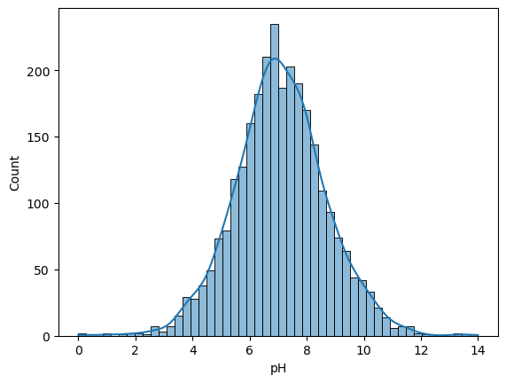

```python
sns.histplot(data=data_raw, x='pH', kde=True)
```

Al respecto del diccionario de datos podemos señalar un par de puntos:

1. Menciona que la variable Apta (Indica si el agua es segura para el consumo, donde SI significa apta y NO significa no apta.) es de tipo numérica; sin embargo, su contenido es de tipo categórico-texto (Si, No), por lo que se procederá a realizar su debida transformación para poder contar únicamente con variables numéricas para la elaboración de nuestros modelos.
2. Se indica que para el pH su rango de investigación comprende de 6.52 a 6.83 según las normas de la OMS, y según su distribución podemos observar que la mayoría de los datos registrados se concentran en las cercanías de este rango; sin embargo, como veremos justo a continuación, la mayoría de las muestras tomadas no se consideran Aptas.

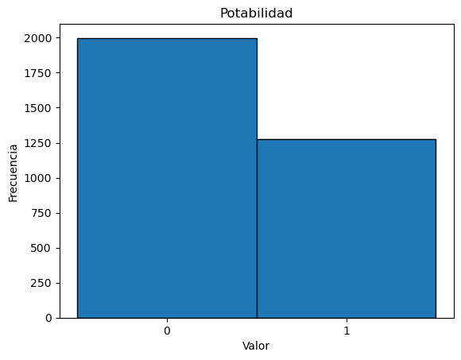

```python
# Crear el histograma con bins específicos
plt.hist(data_raw['Potabilidad'], bins=[-0.5, 0.5, 1.5], edgecolor='black')

# Añadir etiquetas y título
plt.xticks([0, 1], ['0', '1'])
plt.xlabel('Valor')
plt.ylabel('Frecuencia')
plt.title('Potabilidad')

# Mostrar el histograma
plt.show()
```

```python
pd.Series(data_raw['Potabilidad']).value_counts()
```

```
Potabilidad
NO    1998
SI    1278
Name: count, dtype: int64
```

La distribución de la variable objetivo (Apta) nos indica que contamos con una recolección desbalanceada de datos, contando con mayor información para aquellas que han sido etiquedas como "No Apta". Este desbalance podría influir en el aprendizaje de nuestro modelo, por lo que herramientas como el sobre-muestreo o submuestreo serán consideradas para nuestra evaluación.

Adicionalmente, conviene evaluar la calidad de los datos, y de acuerdo con este análisis y los algoritmos a utilizar tomar las decisiones de cómo proceder con valores ausentes y registros duplicados.

```python
data_raw.duplicated().sum()
```

```
0
```

Validamos que no se encuentran datos duplicados, razór por la cual no debemos realizar proceso adicional.

```python
data_raw.isna().sum()
```

```
pH                  491
Dureza                0
Sólidos               0
Cloraminas            0
Sulfatos            781
Conductividad         0
Carbono_orgánico      0
Trihalometanos      162
Turbidez              0
Potabilidad           0
dtype: int64
```

```python
data_raw.isna().sum()/data_raw.shape[0]
```

```
pH                  0.149878
Dureza              0.000000
Sólidos             0.000000
Cloraminas          0.000000
Sulfatos            0.238400
Conductividad       0.000000
Carbono_orgánico    0.000000
Trihalometanos      0.049451
Turbidez            0.000000
Potabilidad         0.000000
dtype: float64
```

Al contrario de los datos duplicados, encontramos un numero significativo de datos ausentes. En lugar de solamente eliminar los "NA" (valores ausentes), podemos ver que representan una porción significativa del total de datos, como 23.84% de las observaciones en la categoría de Sulfatos, 14.99% en PH y 4.95% en Trihalometanos.

```python
pd.Series(data_raw.dropna()['Potabilidad']).value_counts()
```

```
Potabilidad
NO    1200
SI     811
Name: count, dtype: int64
```

```python
porc_registros_sin_datos_ausentes = data_raw.dropna().shape[0]/data_raw.shape[0]
print(f"Porcentaje de registros perdidos por ausencias: {(1-porc_registros_sin_datos_ausentes)*100:.2f}%")
```

```
Porcentaje de registros perdidos por ausencias: 38.61%
```

Dado que nuestros datos ausentes se producen en diferente categorías independientes, en caso de decidir su eliminación estariamos prescindiendo de 1265 registros, lo que representa un 38.61% de los datos registrados. Por tanto, a fin de no perder la diversidad de datos con los que contamos, procederemos a conservarlos y a imputarlos por alguno de los medios conocidos.

No se identifican variables poco relevantes, considerando que todas presentan algún grado de distribución.

## Limpieza y preparacion

```python
data = data_raw.copy()
```

En este caso, no se identifican variables poco relevantes, y dado que todas presentan alguna distribución (aporte de explicabilidad para el modelo) éstas serán conservadas y no se procederá a reducir las dimensiones de los datos.

### Tratamiento de nulos y duplicados

Para el caso de valores ausentes proceremos a una imputación de estos a partir de la mediana. Este proceso lo asignaremos a una etapa que se ejecutará en el pipeline de preparación de datos en el subconjunto de entrenamiento.

```python
simple_imputer = SimpleImputer(strategy='median')
```

### Transformación de variables

Por su parte, aunque tanto el modelo de árbol de decisión puede trabajar con variables categôricas, no asî la implementaciôn de scikit-learn, que requiere que todos los valores sean numéricos. Por tanto, por medio de una codificación LabelEncoder procederemos a hacer una transformación numérica binaria bajo 1-de-1, de esta forma la dicotomía No/Sí será convertida a 0/1.

```python
encoder = LabelEncoder()
data['Potabilidad'] = encoder.fit_transform(data['Potabilidad'])
```

```python
scaler = StandardScaler()
```

```python
numeric_features = ['pH','Dureza','Sólidos','Cloraminas','Sulfatos','Conductividad','Carbono_orgánico','Trihalometanos','Turbidez']

column_transformer = ColumnTransformer(
    transformers = [
        ("num", scaler, numeric_features)
    ],
    verbose_feature_names_out=False
)
```

### Creación del Pipeline de preparación de datos

```python
steps = [
    ("imputer", simple_imputer),
    ("transformer",column_transformer)
]
```

```python
pipeline = Pipeline(steps).set_output(transform='pandas')
```

```python
data.head()
```

|  | pH | Dureza | Sólidos | Cloraminas | Sulfatos | Conductividad | Carbono_orgánico | Trihalometanos | Turbidez | Potabilidad |
| --- | --- | --- | --- | --- | --- | --- | --- | --- | --- | --- |
| 0 | NaN | 204.89 | 20791.32 | 7.30 | 368.52 | 564.31 | 10.38 | 86.99 | 2.96 | 0 |
| 1 | 3.72 | 129.42 | 18630.06 | 6.64 | NaN | 592.89 | 15.18 | 56.33 | 4.50 | 0 |
| 2 | 8.10 | 224.24 | 19909.54 | 9.28 | NaN | 418.61 | 16.87 | 66.42 | 3.06 | 0 |
| 3 | 8.32 | 214.37 | 22018.42 | 8.06 | 356.89 | 363.27 | 18.44 | 100.34 | 4.63 | 0 |
| 4 | 9.09 | 181.10 | 17978.99 | 6.55 | 310.14 | 398.41 | 11.56 | 32.00 | 4.08 | 0 |

```python
data.describe()
```

|  | pH | Dureza | Sólidos | Cloraminas | Sulfatos | Conductividad | Carbono_orgánico | Trihalometanos | Turbidez | Potabilidad |
| --- | --- | --- | --- | --- | --- | --- | --- | --- | --- | --- |
| count | 2785.000000 | 3276.000000 | 3276.000000 | 3276.000000 | 2495.000000 | 3276.000000 | 3276.000000 | 3114.000000 | 3276.000000 | 3276.000000 |
| mean | 7.080804 | 196.369481 | 22014.092415 | 7.122241 | 333.775784 | 426.205171 | 14.284921 | 66.396281 | 3.966731 | 0.390110 |
| std | 1.594369 | 32.879680 | 8768.570852 | 1.583143 | 41.416864 | 80.824123 | 3.308232 | 16.174983 | 0.780354 | 0.487849 |
| min | 0.000000 | 47.430000 | 320.940000 | 0.350000 | 129.000000 | 181.480000 | 2.200000 | 0.740000 | 1.450000 | 0.000000 |
| 25% | 6.090000 | 176.847500 | 15666.687500 | 6.130000 | 307.695000 | 365.735000 | 12.070000 | 55.847500 | 3.440000 | 0.000000 |
| 50% | 7.040000 | 196.965000 | 20927.830000 | 7.130000 | 333.070000 | 421.885000 | 14.220000 | 66.620000 | 3.955000 | 0.000000 |
| 75% | 8.060000 | 216.670000 | 27332.760000 | 8.112500 | 359.950000 | 481.790000 | 16.560000 | 77.337500 | 4.500000 | 1.000000 |
| max | 14.000000 | 323.120000 | 61227.200000 | 13.130000 | 481.030000 | 753.340000 | 28.300000 | 124.000000 | 6.740000 | 1.000000 |

```python
data.info()
```

```
<class 'pandas.core.frame.DataFrame'>
RangeIndex: 3276 entries, 0 to 3275
Data columns (total 10 columns):
 #   Column            Non-Null Count  Dtype
---  ------            --------------  -----
 0   pH                2785 non-null   float64
 1   Dureza            3276 non-null   float64
 2   Sólidos           3276 non-null   float64
 3   Cloraminas        3276 non-null   float64
 4   Sulfatos          2495 non-null   float64
 5   Conductividad     3276 non-null   float64
 6   Carbono_orgánico  3276 non-null   float64
 7   Trihalometanos    3114 non-null   float64
 8   Turbidez          3276 non-null   float64
 9   Potabilidad       3276 non-null   int32
dtypes: float64(9), int32(1)
memory usage: 243.3 KB
```

### Creación del Pipeline

Ahora bien, procedemos a preservar un subconjunto para pruebas, entrenando nuestros modelos con el 80% del total de los datos disponibles.

```python
train, test = train_test_split(data, test_size=0.2, random_state=77)
train.head()
```

|  | pH | Dureza | Sólidos | Cloraminas | Sulfatos | Conductividad | Carbono_orgánico | Trihalometanos | Turbidez | Potabilidad |
| --- | --- | --- | --- | --- | --- | --- | --- | --- | --- | --- |
| 3126 | 6.67 | 155.71 | 30610.05 | 8.17 | 337.17 | 425.69 | 15.10 | 79.78 | 4.90 | 1 |
| 3147 | 6.26 | 130.37 | 9734.68 | 10.28 | 320.36 | 399.35 | 10.85 | 43.42 | 3.93 | 1 |
| 2844 | 6.66 | 182.39 | 16828.88 | 7.07 | 355.90 | 434.66 | 16.62 | 69.41 | 3.97 | 1 |
| 1916 | 8.02 | 255.26 | 30854.83 | 8.76 | NaN | 442.50 | 11.09 | 93.27 | 5.32 | 1 |
| 1053 | 8.92 | 207.52 | 13291.92 | 8.56 | 357.94 | 468.54 | 15.69 | 107.28 | 4.08 | 0 |

### División de datos

De nuestro subconjunto de entrenamiento, separamos nuestra variable objetivo.

```python
x_train = train.drop(['Potabilidad'],axis="columns")
y_train = train['Potabilidad']
```

```python
x_train
```

|  | pH | Dureza | Sólidos | Cloraminas | Sulfatos | Conductividad | Carbono_orgánico | Trihalometanos | Turbidez |
| --- | --- | --- | --- | --- | --- | --- | --- | --- | --- |
| 3126 | 6.67 | 155.71 | 30610.05 | 8.17 | 337.17 | 425.69 | 15.10 | 79.78 | 4.90 |
| 3147 | 6.26 | 130.37 | 9734.68 | 10.28 | 320.36 | 399.35 | 10.85 | 43.42 | 3.93 |
| 2844 | 6.66 | 182.39 | 16828.88 | 7.07 | 355.90 | 434.66 | 16.62 | 69.41 | 3.97 |
| 1916 | 8.02 | 255.26 | 30854.83 | 8.76 | NaN | 442.50 | 11.09 | 93.27 | 5.32 |
| 1053 | 8.92 | 207.52 | 13291.92 | 8.56 | 357.94 | 468.54 | 15.69 | 107.28 | 4.08 |
| ... | ... | ... | ... | ... | ... | ... | ... | ... | ... |
| 1317 | 6.77 | 194.64 | 15719.49 | 6.75 | 339.00 | 441.73 | 22.89 | 75.47 | 3.24 |
| 2283 | NaN | 229.74 | 22709.39 | 6.36 | 316.23 | 294.17 | 16.10 | 54.59 | 4.80 |
| 2004 | 7.50 | 236.71 | 21736.37 | 6.59 | 407.31 | 299.19 | 20.74 | 68.31 | 4.24 |
| 607 | 9.65 | 205.21 | 8508.15 | 4.95 | 386.54 | 392.77 | 12.45 | 53.90 | 3.19 |
| 2775 | 4.87 | 114.46 | 32858.48 | 7.47 | 365.30 | 533.30 | 16.15 | 45.65 | 5.07 |

2620 rows × 9 columns

### Aplicación de Pipeline

Ahora bien, ya contamos con nuestro subconjunto de entrenamiento separado de nuestra variable objetivo, por lo que podemos aplicar los pasos definidos para nuestro pipeline, que incluyen la imputación de datos faltantes.

```python
x_train_transformed = pipeline.fit_transform(x_train)
x_train_transformed
```

|  | pH | Dureza | Sólidos | Cloraminas | Sulfatos | Conductividad | Carbono_orgánico | Trihalometanos | Turbidez |
| --- | --- | --- | --- | --- | --- | --- | --- | --- | --- |
| 3126 | -0.286625 | -1.239460 | 0.987408 | 0.647970 | 0.099009 | 0.003071 | 0.248740 | 0.857889 | 1.186226 |
| 3147 | -0.568319 | -2.003064 | -1.390632 | 1.971714 | -0.370074 | -0.322546 | -1.044780 | -1.458827 | -0.045515 |
| 2844 | -0.293495 | -0.435477 | -0.582489 | -0.042134 | 0.621670 | 0.113959 | 0.711364 | 0.197154 | 0.005278 |
| 1916 | 0.640906 | 1.760412 | 1.015292 | 1.018116 | -0.011494 | 0.210878 | -0.971734 | 1.717419 | 1.719558 |
| 1053 | 1.259260 | 0.321799 | -0.985405 | 0.892643 | 0.678596 | 0.532786 | 0.428312 | 2.610081 | 0.144960 |
| ... | ... | ... | ... | ... | ... | ... | ... | ... | ... |
| 1317 | -0.217919 | -0.066331 | -0.708866 | -0.242892 | 0.150076 | 0.201359 | 2.619687 | 0.583273 | -0.921703 |
| 2283 | -0.025542 | 0.991384 | 0.087396 | -0.487565 | -0.485321 | -1.622788 | 0.553098 | -0.747118 | 1.059243 |
| 2004 | 0.283635 | 1.201420 | -0.023447 | -0.343270 | 2.056266 | -1.560731 | 1.965318 | 0.127066 | 0.348134 |
| 607 | 1.760813 | 0.252189 | -1.530354 | -1.372152 | 1.476680 | -0.403888 | -0.557808 | -0.791082 | -0.985195 |
| 2775 | -1.523332 | -2.482502 | 1.243540 | 0.208813 | 0.883977 | 1.333354 | 0.568316 | -1.316740 | 1.402099 |

2620 rows × 9 columns

## Modelado

### Árbol de decisión

Primero procedemos a crear una clase DecisionTreeClassifier(), que nos servirá para la búsqueda de los hiperparámetros.

```python
decision_tree = DecisionTreeClassifier(random_state=0)
```

```python
param_grid = {
    'criterion': ['gini','entropy'],
    'max_depth': [4,6,8,10,12],
    'min_samples_split': [3,4,5]
}
```

```python
kfold = KFold(n_splits=10, shuffle=True, random_state=0)
```

```python
grid_dt = GridSearchCV(decision_tree, param_grid, cv=kfold, n_jobs=-1)
```

```python
grid_dt.fit(x_train_transformed,y_train)
```

```
GridSearchCV(cv=KFold(n_splits=10, random_state=0, shuffle=True),
             estimator=DecisionTreeClassifier(random_state=0), n_jobs=-1,
             param_grid={'criterion': ['gini', 'entropy'],
                         'max_depth': [4, 6, 8, 10, 12],
                         'min_samples_split': [3, 4, 5]})
```

```python
print("Mejores parámetros: {}".format(grid_dt.best_params_))
```

```
Mejores parámetros: {'criterion': 'entropy', 'max_depth': 10, 'min_samples_split': 4}
```

```python
mejor_modelo_dt = grid_dt.best_estimator_
```

```python
importancia_dt = mejor_modelo_dt.feature_importances_
importancia_dt
```

```
array([0.21767377, 0.11553729, 0.17599153, 0.06064926, 0.20565964,
       0.07349527, 0.08962216, 0.01887386, 0.04249723])
```

```python
importancia_df_dt = pd.DataFrame(
    data={
        'Variable':x_train.columns,
        'Importancia':importancia_dt}
)
importancia_df_dt.sort_values('Importancia', ascending=False)
```

|  | Variable | Importancia |
| --- | --- | --- |
| 0 | pH | 0.217674 |
| 4 | Sulfatos | 0.205660 |
| 2 | Sólidos | 0.175992 |
| 1 | Dureza | 0.115537 |
| 6 | Carbono_orgánico | 0.089622 |
| 5 | Conductividad | 0.073495 |
| 3 | Cloraminas | 0.060649 |
| 8 | Turbidez | 0.042497 |
| 7 | Trihalometanos | 0.018874 |

De acuerdo con estos resultados, la variable pH es una de las que más importancia tiene en nuestro modelo, considerando que es una de las que presentó más valores ausentes.

Para ayudarnos un poco en la comprensión de este modelo, haremos uso de plot_tree para visualizar

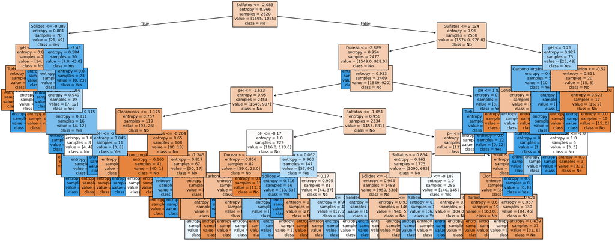

```python
plt.figure(figsize=(25,10))
tree = plot_tree(
    mejor_modelo_dt,
    feature_names=x_train.columns,
    class_names=['No','Yes'],
    filled=True,
    fontsize=9
)
```

### Para K-vecinos

```python
k_values = list(range(1,6,1))
k_values
```

```
[1, 2, 3, 4, 5]
```

```python
train_scores, val_scores = validation_curve(estimator=KNeighborsClassifier(),
                                            X=x_train_transformed,
                                            y=y_train,
                                            param_name='n_neighbors',
                                            param_range=k_values,
                                            scoring='accuracy',
                                            cv=10)
```

```python
train_mean = np.mean(train_scores, axis=1)
train_std = np.std(train_scores, axis=1)
val_mean = np.mean(val_scores, axis=1)
val_std = np.std(val_scores, axis=1)
```

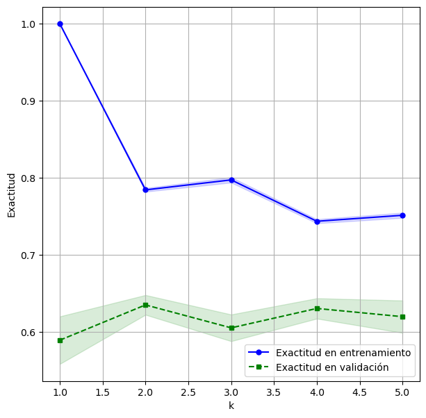

```python
# Inicializamos la figura
plt.figure(figsize=(7,7))

# Creamos la curva de validación para el conjunto de entrenamiento
plt.plot(k_values, train_mean, color='blue', marker='o', markersize=5, label='Exactitud en entrenamiento')
plt.fill_between(k_values, train_mean+train_std, train_mean-train_std, alpha=0.15, color='blue')

# Creamos la curva de validación para el conjunto de validación
plt.plot(k_values, val_mean, color='green', linestyle='--', marker='s', markersize=5, label='Exactitud en validación')
plt.fill_between(k_values, val_mean+val_std, val_mean-val_std, alpha=0.15, color='green')

# Agregamos una grilla y etiquetas para los ejes
plt.grid()
plt.legend(loc='lower right')
plt.xlabel('k')
plt.ylabel('Exactitud')
plt.show()
```

```python
mejor_indice = np.argmax(val_mean)
mejor_indice
```

```
1
```

```python
mejor_k = k_values[mejor_indice]
mejor_k
```

```
2
```

```python
mejor_modelo_kn = KNeighborsClassifier(n_neighbors=mejor_k).fit(x_train_transformed,y_train)
```

## Evaluación del mejor modelo

```python
x_test = test.drop(['Potabilidad'],axis=1)
y_test = test['Potabilidad']
```

```python
x_test_transformed = pipeline.transform(x_test)
x_test_transformed
```

|  | pH | Dureza | Sólidos | Cloraminas | Sulfatos | Conductividad | Carbono_orgánico | Trihalometanos | Turbidez |
| --- | --- | --- | --- | --- | --- | --- | --- | --- | --- |
| 2133 | 0.029423 | -0.697645 | -0.299898 | -0.380912 | 1.086009 | -1.607707 | -2.134381 | 1.431971 | -0.718529 |
| 761 | 1.898225 | 0.358563 | 1.520443 | 0.760896 | 0.100126 | 0.457872 | -1.270005 | -0.982868 | 0.703688 |
| 2269 | 0.208058 | -0.557521 | -1.026789 | 0.434665 | -0.011494 | -0.605143 | 1.164857 | -1.651249 | -0.147102 |
| 807 | 1.911967 | 0.811482 | 0.866613 | 0.365654 | -1.465066 | -0.856216 | -0.025182 | 1.127408 | 0.983052 |
| 2044 | -0.025542 | -2.649446 | -0.850481 | -1.089837 | -1.462834 | 1.072885 | 0.221348 | 1.296893 | -0.083611 |
| ... | ... | ... | ... | ... | ... | ... | ... | ... | ... |
| 1713 | 1.190554 | -0.635568 | 0.140245 | -0.255439 | 0.935601 | 1.565390 | -1.994376 | 1.600818 | -0.134404 |
| 1115 | 1.149330 | -0.344169 | 1.036487 | 0.880095 | -0.011494 | -0.214378 | 1.204424 | 0.381293 | -0.197896 |
| 2322 | 1.424154 | 1.342148 | 0.709549 | -0.198976 | -1.982704 | 1.767510 | -1.875677 | -1.150441 | -0.540752 |
| 605 | -0.410295 | -0.722657 | -0.833482 | 0.378202 | 0.440288 | 2.807407 | -1.239569 | -0.596748 | 0.894164 |
| 2527 | -0.025542 | -1.714076 | 1.079804 | -0.318176 | 0.357689 | -0.576957 | 0.991373 | -0.733738 | 0.729085 |

656 rows × 9 columns

```python
y_pred_dt = mejor_modelo_dt.predict(x_test_transformed)
```

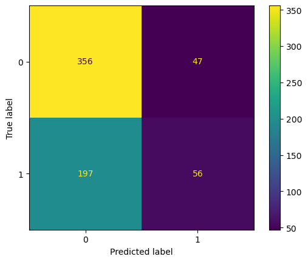

```python
ConfusionMatrixDisplay.from_estimator(mejor_modelo_dt, x_test_transformed,y_test)
plt.show()
```

```python
print(classification_report(y_test, y_pred_dt))
```

```
              precision    recall  f1-score   support

           0       0.64      0.88      0.74       403
           1       0.54      0.22      0.31       253

    accuracy                           0.63       656
   macro avg       0.59      0.55      0.53       656
weighted avg       0.61      0.63      0.58       656
```

```python
x_clasif = x_test_transformed.iloc[1]
x_clasif
```

```
pH                  1.898225
Dureza              0.358563
Sólidos             1.520443
Cloraminas          0.760896
Sulfatos            0.100126
Conductividad       0.457872
Carbono_orgánico   -1.270005
Trihalometanos     -0.982868
Turbidez            0.703688
Name: 761, dtype: float64
```

```python
y_pred_kn = mejor_modelo_kn.predict(x_test_transformed)
```

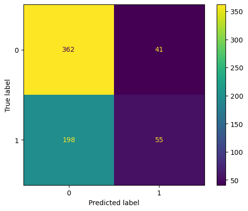

```python
ConfusionMatrixDisplay.from_estimator(mejor_modelo_kn, x_test_transformed, y_test)
plt.show()
```

```python
print(classification_report(y_test, y_pred_kn))
```

```
              precision    recall  f1-score   support

           0       0.65      0.90      0.75       403
           1       0.57      0.22      0.32       253

    accuracy                           0.64       656
   macro avg       0.61      0.56      0.53       656
weighted avg       0.62      0.64      0.58       656
```

```python
accuracy_test_dt = accuracy_score(y_test, y_pred_dt)
recall_test_dt = recall_score(y_test, y_pred_dt,pos_label=0)
precision_test_dt = precision_score(y_test, y_pred_dt)
f1_score_test_dt = f1_score(y_test, y_pred_dt)

accuracy_test_kn = accuracy_score(y_test, y_pred_kn)
recall_test_kn = recall_score(y_test, y_pred_kn,pos_label=0)
precision_test_kn = precision_score(y_test, y_pred_kn)
f1_score_test_kn = f1_score(y_test, y_pred_kn)


df_comparacion = pd.DataFrame({
    "Métrica": ["Exactitud", "Recall", "Precisión", "F1-Score"],
    "Árbol de Decisión Test": [accuracy_test_dt, recall_test_dt, precision_test_dt, f1_score_test_dt],
    "KNN Test": [accuracy_test_kn, recall_test_kn, precision_test_kn, f1_score_test_kn]
})

df_comparacion
```

|  | Métrica | Árbol de Decisión Test | KNN Test |
| --- | --- | --- | --- |
| 0 | Exactitud | 0.628049 | 0.635671 |
| 1 | Recall | 0.883375 | 0.898263 |
| 2 | Precisión | 0.543689 | 0.572917 |
| 3 | F1-Score | 0.314607 | 0.315186 |